# Cartography

Charis Deadwyler

3/10/2021

# Cartography

*“The art or technique of making maps”*

### Factors that affect design

- **Objective:** what information do you want to convey?
- **Audience:** who will be using your map? Is your map easily understood by your target audience?
- **Reality and generalization:** when making a small map using data with a high level of detail, how much of this detail do you want/need to retain? What information can be generalized?
- **Map scale:** is your data better visualized on a small-scale or a large-scale?
- **Technical limits:** are you constrained by printer capability? Does your map need to load quickly if being view online?

### Basic elements of a Map

- Title
- Legend
- Scale
- North arrow
- Additional information: this could be a brief desciption of your map, data sources, projection information, author information ect

### Effective Maps

- Communicates a clear message
- Appropriate projection
- Data at appropriate level of generalization
- Clear symbology: symbols match the data and are easy to distinguish from one another
- Good figure-ground organization (layout)
- Good visual hierarchy: is the reader’s eye drawn to the most important information? This can be achieved through size, color, placement on map layout

# Common Types of Maps

### Dot-Density

- Uses point symbology to visualize a geographic distribution
- Rely on visual scatter to show spatial patterns
- Each dot represents a constant number of things (people, things, any quanifiable phenomena)

[This link provides a walk through of making dot density maps from census data](https://github.com/tarakc02/tarakc02.github.io/blob/master/dot-density/index.md)

`tidycensus` package is used to download population data from the US Census Bureau

`tigris` package is used to download shapefiles from the US Census and load them into R as `sf` objects [Here](https://github.com/walkerke/tigris/blob/master/README.md) is a helpful guide if you are interested in learning more about the `tigris` package.

**Examples of available datasets**

| Function | Datasets available | Years available |
| --- | --- | --- |
| `nation()` | cartographic (1:5m; 1:20m) | 2013-2019 |
| `divisions()` | cartographic (1:500k; 1:5m; 1:20m) | 2013-2019 |
| `regions()` | cartographic (1:500k; 1:5m; 1:20m) | 2013-2019 |
| `states()` | TIGER/Line; cartographic (1:500k; 1:5m; 1:20m) | 1990, 2000, 2010-2019 |
| `counties()` | TIGER/Line; cartographic (1:500k; 1:5m; 1:20m) | 1990, 2000, 2010-2019 |
| `tracts()` | TIGER/Line; cartographic (1:500k) | 1990, 2000, 2010-2019 |
| `block_groups()` | TIGER/Line; cartographic (1:500k) | 1990, 2000, 2010-2019 |
| `blocks()` | TIGER/Line | 2000, 2010-2019 |
| `places()` | TIGER/Line; cartographic (1:500k) | 2011-2019 |
| `pumas()` | TIGER/Line; cartographic (1:500k) | 2012-2019 |
| `school_districts()` | TIGER/Line; cartographic | 2011-2019 |
| `zctas()` | TIGER/Line; cartographic (1:500k) | 2000, 2010, 2012-2019 |
| `congressional_districts()` | TIGER/Line; cartographic (1:500k; 1:5m; 1:20m) | 2011-2019 |
| `state_legislative_districts()` | TIGER/Line; cartographic (1:500k) | 2011-2019 |
| `voting_districts()` | TIGER/Line | 2012 |
| `area_water()` | TIGER/Line | 2011-2019 |
| `linear_water()` | TIGER/Line | 2011-2019 |

```r
library(tigris)

water <- tigris::area_water("51", "760")  # VA is state 51, RVA is county 760
roads <- tigris::roads("51", "760")
counties <- tigris::counties(state = "51") #filter VA data to get a map of Richmond
rva <- counties %>%
  filter(COUNTYFP == 760)
```

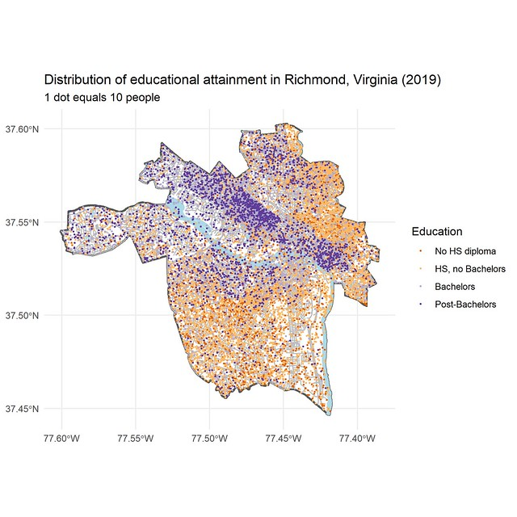

```r
ggplot() +
  geom_sf(data = rva, fill = "white", lwd = 1) +
  geom_sf(data = water, fill = "lightblue", colour = "lightblue") +
  geom_sf(data = roads, colour = "grey") +
  geom_sf(data = points,          #the creation of the points data is shown in a chunk not included in the published document, but is included if you download this markdown file
          aes(colour = education,
              fill = education),
          size = .5) +
  scale_color_brewer(type = "div", palette = 4,
                     name = "Education") +
  scale_fill_brewer(type = "div", palette = 4) +
  theme_minimal() +
  ggtitle("Distribution of educational attainment in Richmond, Virginia (2019)",
            "1 dot equals 10 people") +
  guides(fill = "none")
```

### Proportional Symbols

- Size of symbols is related to the value of phenomenon represented – the larger the symbol the “more” of something exists at that location
- Most basic method is to scale circles directly proportionate to the data
- Can be used with both numeric or ordered catagorical data

For this example I again used data from `tidycensus` and `tigris`. The code for processing this data is availble in the markdown document

Note that the circles are plotted as points, not polygons. Proportionate circle sizes are made using `aes(size = data$attribute)`

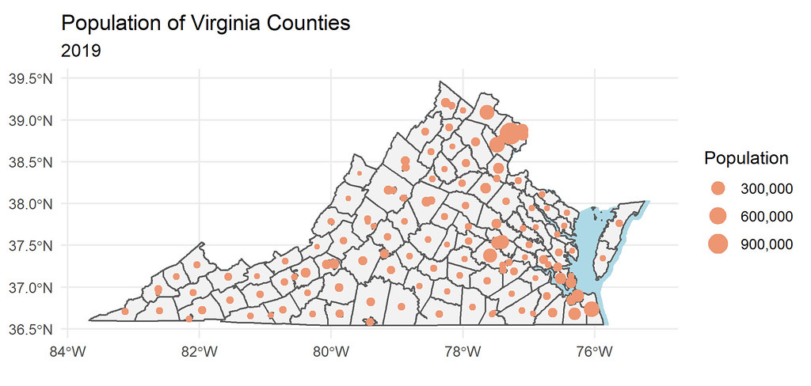

```r
#proportionate circle sizes are made

ggplot() +
  geom_sf(data = counties, fill = "lightblue", color = "lightblue") +
  geom_sf(data = acs, fill = "grey95") +
  geom_sf(data = points, aes(size = estimate), color = "lightsalmon2") +  #data processing for the points data is shown in the previous chunk (visible in the markdown document). Points are created using centroids of county polygons
  theme_minimal() +
  ggtitle("Population of Virginia Counties",
          "2019") +
  labs( size = "Population") +
  scale_size_continuous(labels = comma)
```

### Choropleth

- Represent data through shading or symbols on polygons
- Popular because they easily represent variability data across a region

For this example I again used data from `tidycensus` and `tigris`. The code for processing this data is availble in the markdown document

The scaling of color is made by `aes(fill = data$attribute)`

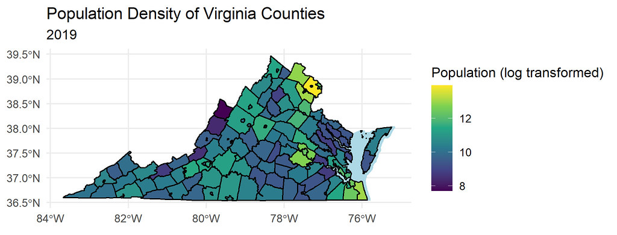

Choropleth

### Isoline

- Lines connect points knows or estimated to have equal vales
- Used in maps of temperature, precipitation, air pressure, climate classifications, ect
- Topographic maps: type of isoline map depicting elevation

The package `ggisobands` can be used to plot isobands into `ggplot2`. x, y, and z values are required in `aes()` The scaled colors are achieved in `aes(fill =)`

[figure not shown]

```r
#DEM <- raster("USGS_one_meter_x28y416_VA_Sandy_2014.tif")

#DEM_5m <- aggregate(DEM, fact = 5)

#DEM_5m <- writeRaster(DEM_5m, filename = file.path("DEM_5m.tif"))

DEM_5m <- raster("DEM_5m.tif")

DEM_pts <- rasterToPoints(DEM_5m, spatial = TRUE)       #I transformed my raster data into a data frame of points, each with an x, y, and z column (z being elevation)
DEM_df <- data.frame(DEM_pts)
DEM_df$DEM_5m <- ifelse(DEM_df$DEM_5m <0, 0, DEM_df$DEM_5m) #There was a section with very negative numbers that I assumed to be a defect in the data, so I made any negative values 0 to clean it up


ggplot(DEM_df, aes(x=x, y=y, z=DEM_5m)) +             #You need an x, y, and z in the aes()
  geom_isobands(aes(fill = stat(zmin)), color = NA) + #the stat function is used to tell ggplot that you want it to use a calculated aesthetic produced by the statistic
  scale_fill_viridis_c()
```

There is a package, `isoband` that generates contour lines that can be used with `grid.path()` or `grid.polyline()` from the `grid` library. To use this data in ggplot it must be converted to an `sf` object. A vignette of that package is available [here](https://github.com/wilkelab/isoband).

[Robin Lovelace](https://geocompr.robinlovelace.net/geometric-operations.html#raster-vector) explain spatial vectorization and shows how to use the `rasterToContour()` function

# Basic Map Making

```r
library("ggplot2")
theme_set(theme_bw())
library("sf")

library("rnaturalearth")
library("rnaturalearthdata")
```

note - `returnclass` default is `sp`

```r
world <- ne_countries(scale = "medium", returnclass = "sf")
class(world)
```

```r
ggplot(world) +
  geom_sf() -> p

p
```

[output not shown]

### Title, subtitle & axis labels

```r
p +
  xlab("Longitude") +
  ylab("Latitude") +
  ggtitle("World Map",
          subtitle = paste0("(" ,length(unique(world$name)), "countries)" )) -> p

p
```

[output not shown]

- `paste()` vs `paste0()`

### Color

`color` -> outline `fill` -> filled color

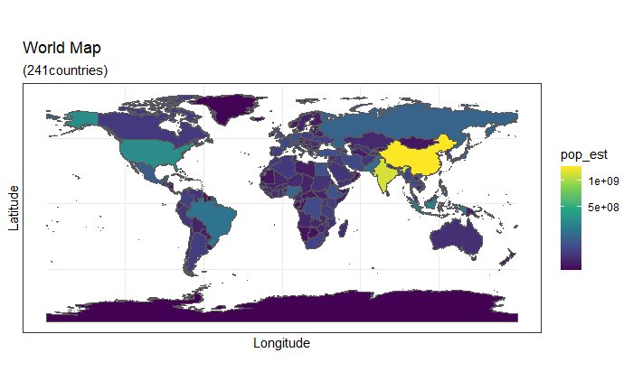

```r
p +
  geom_sf(aes(fill = pop_est)) +
  scale_fill_viridis_c( trans = "sqrt") -> p

p
```

`trans =` transformation of data, in this case square root

`option =` A-E, default is D

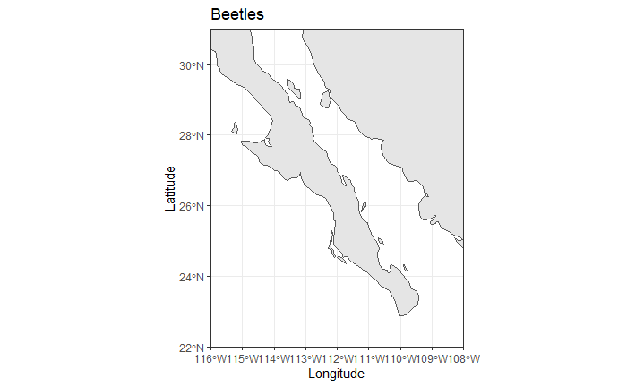

```r
beetle_url <- "https://raw.githubusercontent.com/dyerlab/ENVS-Lectures/master/data/Araptus_Disperal_Bias.csv"

read_csv(beetle_url) %>%
  st_as_sf( coords=c("Longitude","Latitude"), crs=4326 ) %>%
  st_union() %>%
  st_buffer(dist = 1) %>%
  st_bbox() -> bounds

read_csv(beetle_url) %>%
  st_as_sf(coords=c("Longitude","Latitude"), crs = 4326) -> beetle

ggplot(world) +
  geom_sf() +
  xlab("Longitude") +
  ylab("Latitude") +
  ggtitle("Beetles") +
  coord_sf( xlim = c(-116, -108), ylim = c(22, 31), expand = FALSE) -> p

p
```

Scale bar and North arrow package `ggspatial`

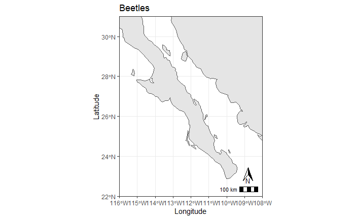

```r
library(ggspatial)

p+
  annotation_scale(location = "br", style = "bar") +
  annotation_north_arrow(location = "br", width = unit(.5, "cm"),
                         height = unit(.75, "cm"),
                         pad_y = unit(0.75, "cm"),
                         pad_x = unit(0.5, "cm"),
                         style = north_arrow_orienteering(
                           text_size = 8
                         )) -> p

p
```

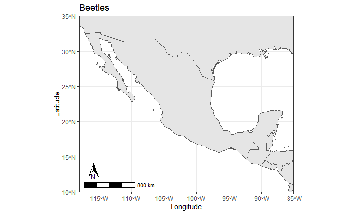

```r
ggplot(world) +
  geom_sf() +
  xlab("Longitude") +
  ylab("Latitude") +
  ggtitle("Beetles") +
  coord_sf( xlim = c(-118, -85),
            ylim = c(10, 35),
            expand = FALSE) +
  annotation_scale(location = "bl",
                   style = "bar") +
  annotation_north_arrow(location = "bl", width = unit(.5, "cm"),
                         height = unit(.75, "cm"),
                         pad_y = unit(0.75, "cm"),
                         pad_x = unit(0.5, "cm"),
                         style = north_arrow_orienteering(
                           text_size = 8
                         )) -> p

p
```

changed extent to see more countries

### Adding names

```r
library(ggrepel)

world_points<- st_centroid(world)
world_points <- cbind(world, st_coordinates(st_centroid(world$geometry)))

my_points <- world_points %>%
  filter( X > -118 & X < -85) %>%
  filter( Y > 10 & Y < 35)

nrow(my_points)
```

```
[1] 6
```

```r
summary(world_points$Y)
```

```
   Min. 1st Qu.  Median    Mean 3rd Qu.    Max.
-80.509   1.359  17.277  17.169  39.116  74.711
```

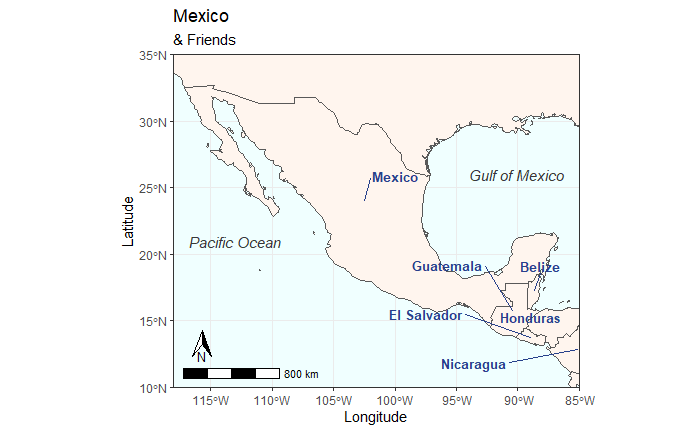

```r
ggplot() +
  geom_sf(data=world, fill = "seashell") +
  xlab("Longitude") +
  ylab("Latitude") +
  ggtitle("Mexico", subtitle = "& Friends") +
  coord_sf( xlim = c(-118, -85),
            ylim = c(10, 35),
            expand = FALSE) +
  annotation_scale(location = "bl",
                   style = "bar") +
  annotation_north_arrow(location = "bl", width = unit(.5, "cm"),
                         height = unit(.75, "cm"),
                         pad_y = unit(0.75, "cm"),
                         pad_x = unit(0.5, "cm"),
                         style = north_arrow_orienteering(
                           text_size = 8
                         )) +
  geom_text_repel(data= my_points,aes(x=X, y=Y, label=name),
                  color = "royalblue4", fontface = "bold",
                  size = 3.5,
                  point.padding = 0,
                  box.padding = unit(.5, "cm"))   +
  annotate(geom = "text",
               x = -90, y = 26,
               label = "Gulf of Mexico",
               fontface = "italic",
               color = "grey22",
               size = 4) +
    annotate(geom = "text",
               x = -113, y = 21,
               label = "Pacific Ocean",
               fontface = "italic",
               color = "grey22",
               size = 4) +
  theme(panel.background = element_rect(fill = "azure")) -> Mexico_map

Mexico_map
```

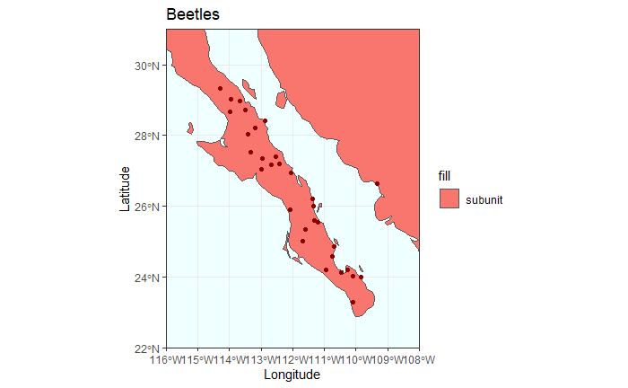

```r
mexico <- ne_countries(scale = "medium", type = "countries", country = "Mexico", returnclass = c("sf"))

ggplot() +
  geom_sf(data = mexico,  aes(fill = "subunit")) +
  geom_sf(data = beetle, color = "darkred") +
  xlab("Longitude") +
  ylab("Latitude") +
  ggtitle("Beetles") +
  coord_sf( xlim = c(-116, -108), ylim = c(22, 31), expand = FALSE) +
  theme(panel.background = element_rect(fill = "azure"))
```